# Steps for Data Import

# Steps for Data Import

1. **Navigate to Exploratory Analysis Tab**

   Click on the `Exploratory Analysis` tab located in the left sidebar of this page.

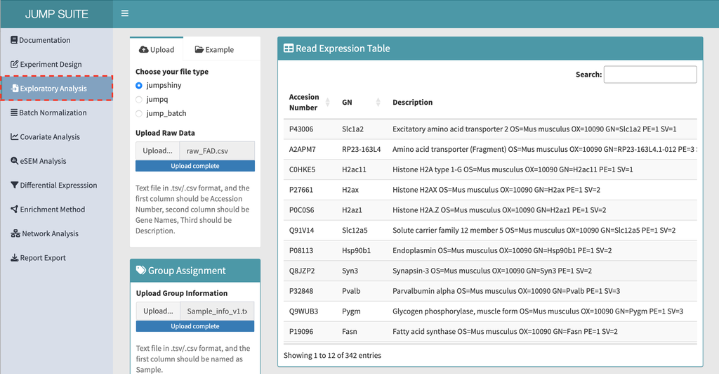

   Data Import Tab

2. **Upload Data**

   Ensure your file follows the correct format shown below. For large datasets (e.g., 50,000 rows in the online version), consider using the offline version.

   Data will be displayed after successful upload.

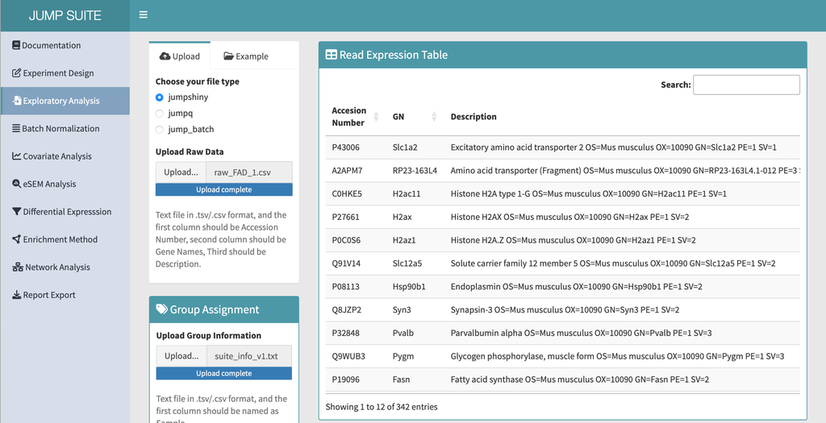

   Import Data

   **JUMP-shiny Data:**

   If your data contains Accession number, Gene Name, Description, and samples, use `jumpshiny` to upload. **The first column is required.**

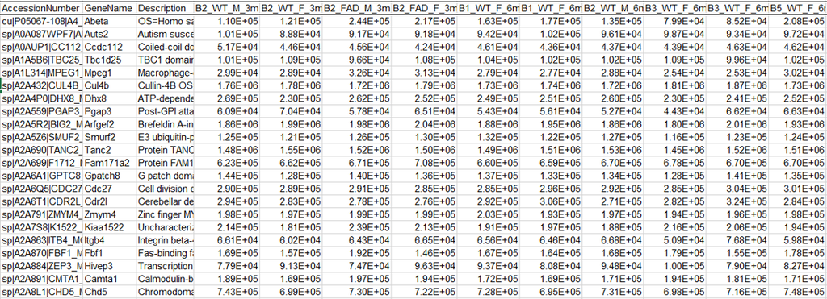

   Jumpshiny

   **JUMPq Result Format:**

   If your data sample starts from the 24th column, use `jumpq` to upload.

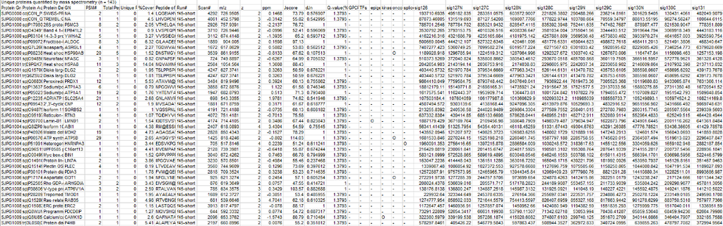

   Jumpq

   **JUMPq Batch Result Format:**

   If your data contains batch info, use `jump_batch` to upload.

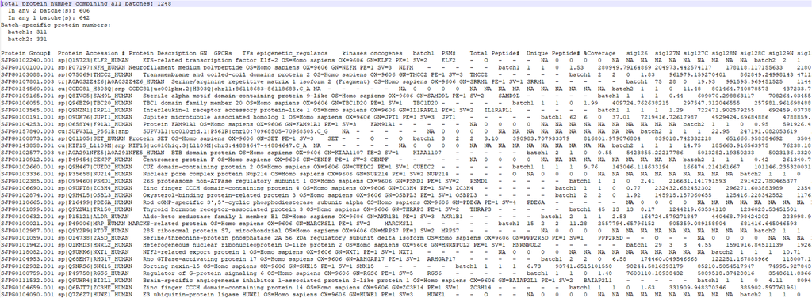

   Jumpq Batch

3. **Group Assignment**

   After loading the dataset, input your grouping in the `[Group Assignment]` panel.

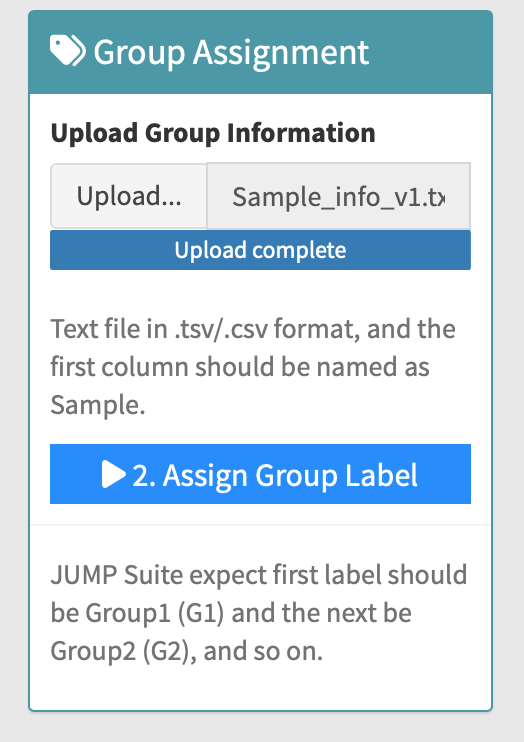

   Group Assignment

   - The first column should be your sample name (matching the column’s name of your input dataset).
   - Only the columns listed here will be included in the analysis.
   - The second column is your grouping name (e.g., “control” or “sample”).
   - Headers are required.

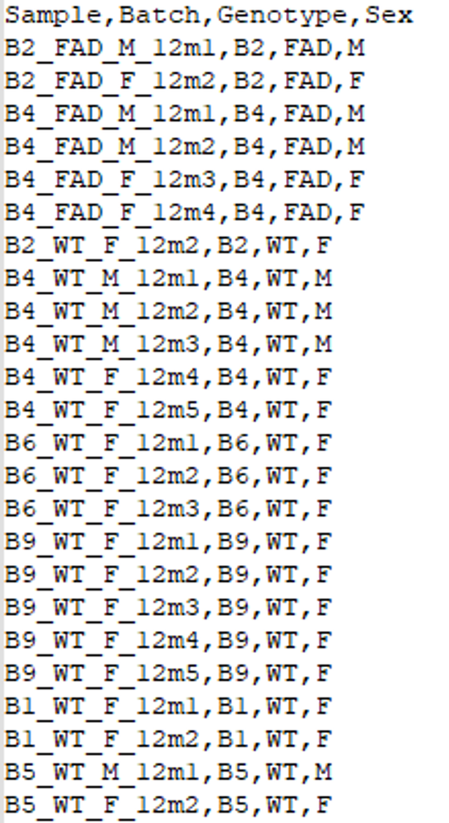

   Group Info

4. **Confirm and Analyze**

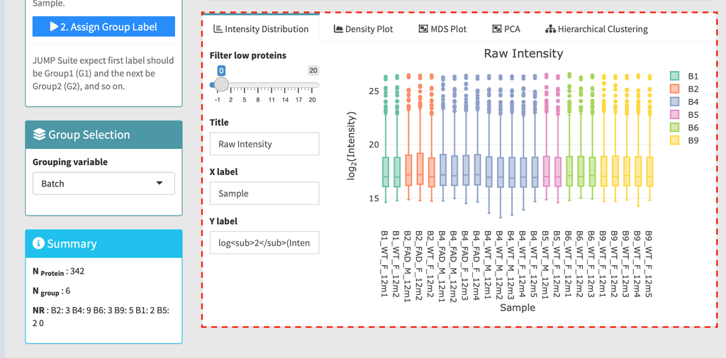

   Distribution

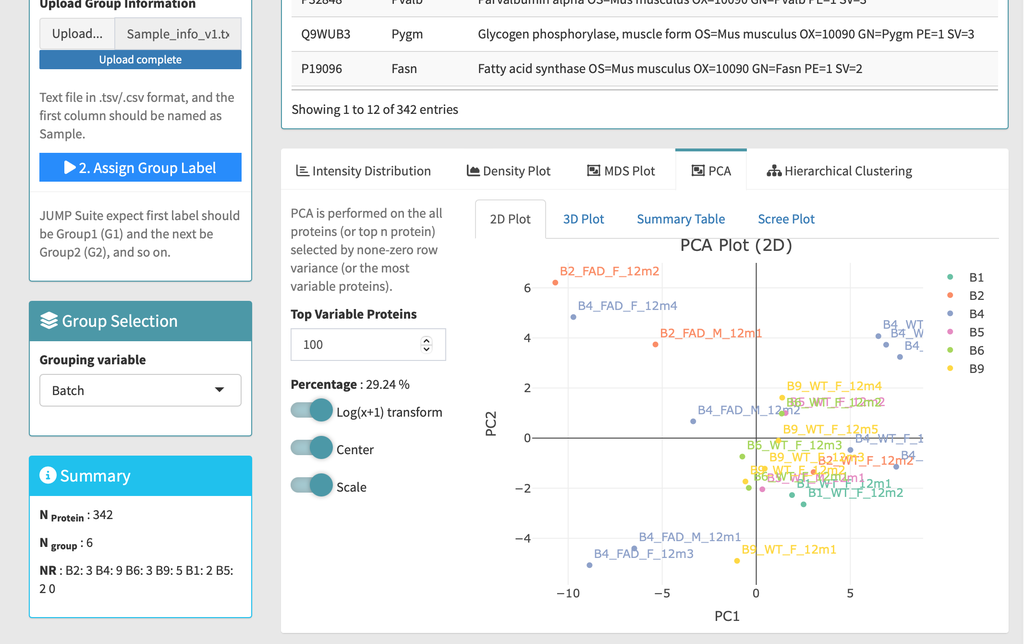

   PCA Plot

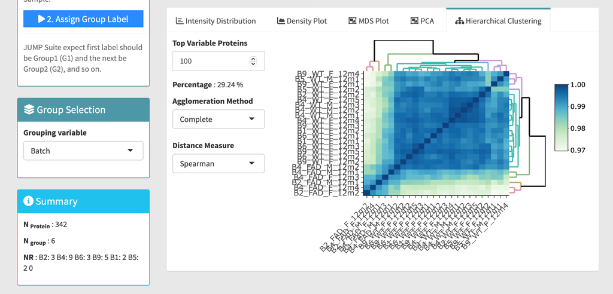

   Heatmap

   Change the group by selecting options in the `[Group Selection]` Panel.

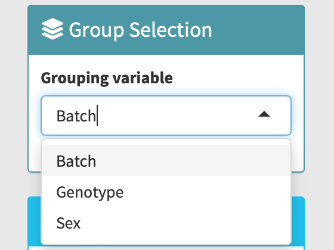

   Group Selection